# Test - AB provost site Normal

Steffi LaZerte

2017-08-25

# Details

7.47 min to run

#### Original Dem (Relief)

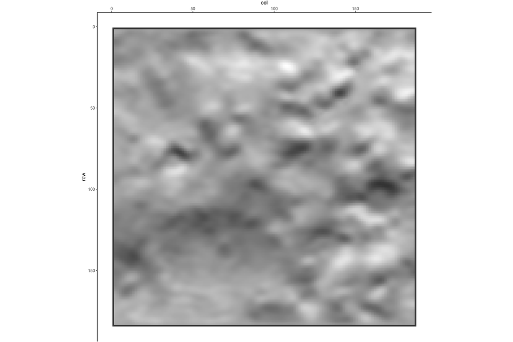

#### Original Dem (Elevation)

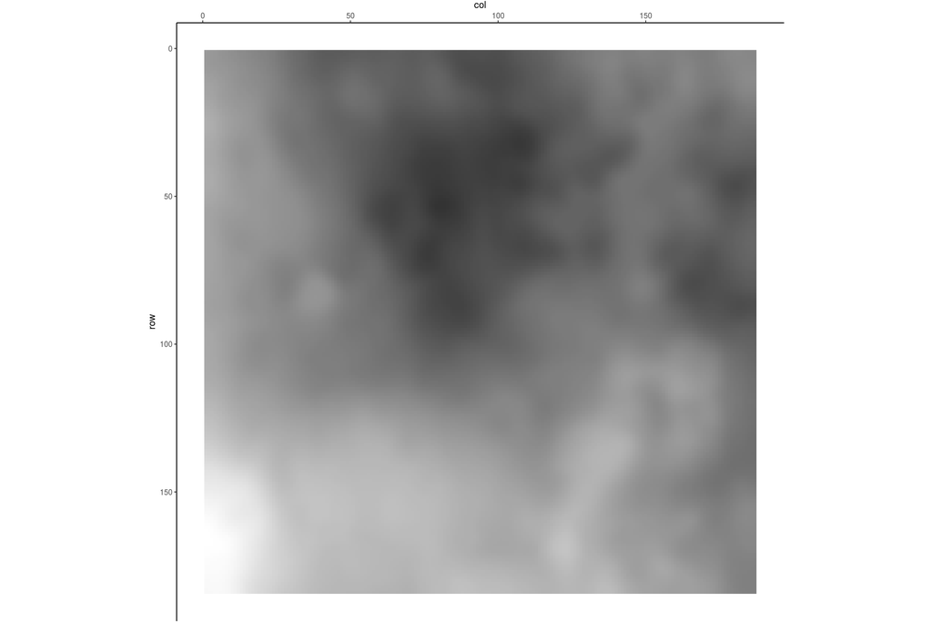

# Visual Comparison

## Original vs. New Local Shed assignment

- These are the local sheds (shedno) after amalgamating the small ones
- Sheds are identical

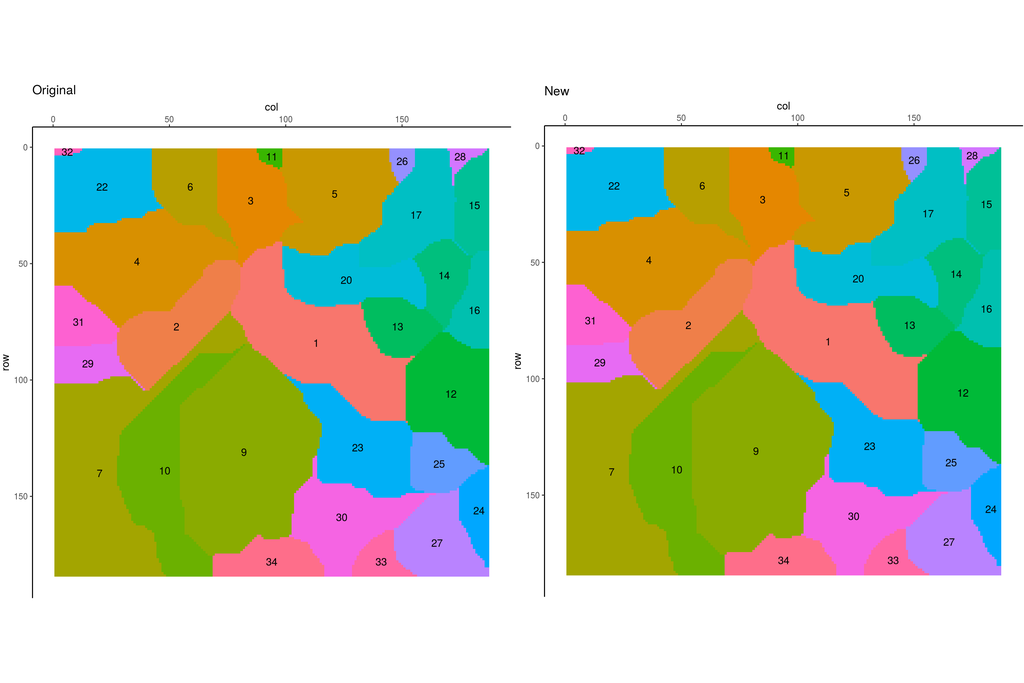

## Original vs. New Pond Shed assignment

- These are the pond sheds, which reflect how sheds combined during the second pit removal process
- Sheds are identical, except that some numbered differently

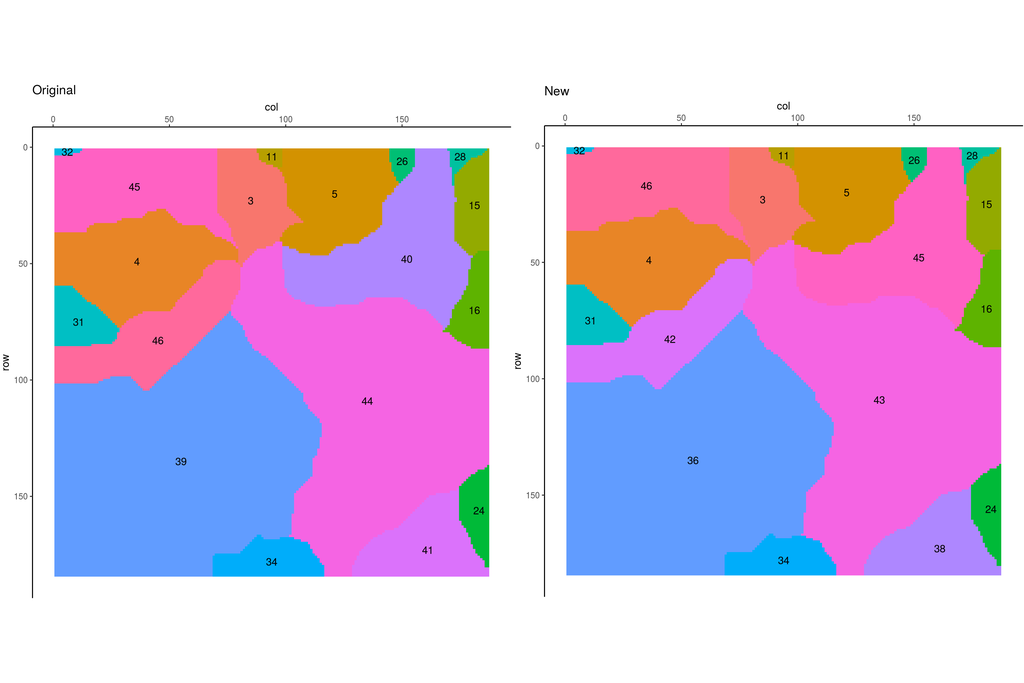

# Numeric Comparison

## Compare pond stats

We know the watersheds have different numbering, so first need to renumber all to match

```r
pond <- shedno_update2(pond) %>% arrange(ShedNo)
orig_pond <- shedno_update2(orig_pond) %>% arrange(ShedNo)
```

**Original Pond data**

|  | ShedNo | Edge | Final | ShedArea | PitRow | PitCol | PitRec | PitElev | PourElev | PreVol | PitVol | Varatio | PitArea | NextPit | Removed | InRow | InCol | InRec | InElev | OutRow | OutCol | OutRec | OutElev | Stage | Visited | Becomes | DrainsTo | EndPit |
| --- | --- | --- | --- | --- | --- | --- | --- | --- | --- | --- | --- | --- | --- | --- | --- | --- | --- | --- | --- | --- | --- | --- | --- | --- | --- | --- | --- | --- |
| 1 | 1 | True | True | 9293 | 165 | 1 | 30669 | 665.34 | 670.724 | 4182.094 | 4721.135 | 508.03 | 2872 | 34 | False | 174 | 77 | 32428 | 670.723 | 175 | 77 | 32615 | 670.724 | 0 | False | 0 | 11 | 0 |
| 2 | 2 | True | False | 5309 | 165 | 1 | 30669 | 665.34 | 670.514 | 3450.528 | 4167.741 | 785.03 | 2108 | 36 | True | 155 | 56 | 28854 | 670.514 | 155 | 57 | 28855 | 670.512 | 0 | False | 1 | 12 | 0 |
| 3 | 3 | True | False | 3287 | 165 | 1 | 30669 | 665.34 | 670.132 | 0 | 3441.443 | 1046.99 | 1483 | 35 | True | 163 | 36 | 30330 | 670.125 | 162 | 37 | 30144 | 670.132 | 1 | False | 2 | 4 | 0 |
| 4 | 4 | False | False | 2022 | 156 | 39 | 29024 | 669.936 | 670.132 | 0 | 9.085 | 4.49 | 110 | 7 | True | 162 | 37 | 30144 | 670.132 | 163 | 36 | 30330 | 670.125 | 1 | False | 2 | 3 | 0 |
| 5 | 5 | True | True | 8306 | 169 | 122 | 31538 | 669.989 | 671.046 | 94.104 | 94.104 | 11.33 | 250 | 38 | False | 184 | 128 | 34349 | 671.046 | 184 | 129 | 34350 | 671.041 | 0 | False | 0 | 13 | 0 |
| 6 | 6 | True | True | 7669 | 169 | 122 | 31538 | 669.989 | 671.046 | 94.104 | 94.104 | 12.27 | 250 | 38 | True | 184 | 128 | 34349 | 671.046 | 184 | 129 | 34350 | 671.041 | 0 | False | 5 | 13 | 0 |
| 7 | 7 | True | True | 7072 | 169 | 122 | 31538 | 669.989 | 671.046 | 94.104 | 94.104 | 13.31 | 250 | 38 | True | 184 | 128 | 34349 | 671.046 | 184 | 129 | 34350 | 671.041 | 0 | False | 6 | 13 | 0 |
| 8 | 8 | True | True | 5566 | 169 | 122 | 31538 | 669.989 | 671.046 | 94.104 | 94.104 | 16.91 | 250 | 38 | True | 184 | 128 | 34349 | 671.046 | 184 | 129 | 34350 | 671.041 | 0 | False | 7 | 13 | 0 |
| 9 | 9 | True | True | 2867 | 169 | 122 | 31538 | 669.989 | 671.046 | 94.104 | 94.104 | 32.82 | 250 | 38 | True | 184 | 128 | 34349 | 671.046 | 184 | 129 | 34350 | 671.041 | 0 | False | 8 | 14 | 0 |
| 10 | 10 | True | True | 1377 | 169 | 122 | 31538 | 669.989 | 671.046 | 0 | 94.104 | 68.34 | 250 | 38 | True | 184 | 128 | 34349 | 671.046 | 184 | 129 | 34350 | 671.041 | 1 | False | 9 | 14 | 0 |

[output cut: 32 more lines]

**New Pond data**

|  | ShedNo | Edge | Final | ShedArea | PitRow | PitCol | PitRec | PitElev | PourElev | PreVol | PitVol | Varatio | PitArea | NextPit | Removed | InRow | InCol | InRec | InElev | OutRow | OutCol | OutRec | OutElev | Stage | Visited | Becomes | DrainsTo | EndPit |
| --- | --- | --- | --- | --- | --- | --- | --- | --- | --- | --- | --- | --- | --- | --- | --- | --- | --- | --- | --- | --- | --- | --- | --- | --- | --- | --- | --- | --- |
| 1 | 1 | True | True | 9293 | 164 | 1 | 30482 | 665.34 | 670.724 | 0 | 4721.136 | 508.03 | 2873 | 34 | False | 174 | 77 | 32428 | 670.723 | 175 | 77 | 32615 | 670.724 | 0 | False | 0 | 11 | 0 |
| 2 | 2 | True | False | 5309 | 164 | 1 | 30482 | 665.34 | 670.514 | 0 | 4167.741 | 785.03 | 2109 | 9 | True | 155 | 56 | 28854 | 670.514 | 154 | 57 | 28668 | 670.512 | 0 | False | 1 | 12 | 0 |
| 3 | 3 | True | False | 3287 | 164 | 1 | 30482 | 665.34 | 670.132 | 0 | 3441.443 | 1046.99 | 1483 | 10 | True | 163 | 36 | 30330 | 670.125 | 162 | 37 | 30144 | 670.132 | 0 | False | 2 | 4 | 0 |
| 4 | 4 | False | False | 2022 | 156 | 39 | 29024 | 669.936 | 670.132 | 0 | 9.085 | 4.49 | 110 | 7 | True | 162 | 37 | 30144 | 670.132 | 163 | 36 | 30330 | 670.125 | 0 | False | 2 | 3 | 0 |
| 5 | 5 | True | True | 8306 | 169 | 122 | 31538 | 669.989 | 671.046 | 0 | 94.104 | 11.33 | 250 | 38 | False | 184 | 128 | 34349 | 671.046 | 184 | 129 | 34350 | 671.041 | 0 | False | 0 | 13 | 0 |
| 6 | 6 | True | True | 7669 | 169 | 122 | 31538 | 669.989 | 671.046 | 0 | 94.104 | 12.27 | 250 | 38 | True | 184 | 128 | 34349 | 671.046 | 184 | 129 | 34350 | 671.041 | 0 | False | 5 | 13 | 0 |
| 7 | 7 | True | True | 7072 | 169 | 122 | 31538 | 669.989 | 671.046 | 0 | 94.104 | 13.31 | 250 | 38 | True | 184 | 128 | 34349 | 671.046 | 184 | 129 | 34350 | 671.041 | 0 | False | 6 | 13 | 0 |
| 8 | 8 | True | True | 5566 | 169 | 122 | 31538 | 669.989 | 671.046 | 0 | 94.104 | 16.91 | 250 | 38 | True | 184 | 128 | 34349 | 671.046 | 184 | 129 | 34350 | 671.041 | 0 | False | 7 | 13 | 0 |
| 9 | 9 | True | True | 2867 | 169 | 122 | 31538 | 669.989 | 671.046 | 0 | 94.104 | 32.82 | 250 | 33 | True | 184 | 128 | 34349 | 671.046 | 184 | 129 | 34350 | 671.041 | 0 | False | 8 | 14 | 0 |
| 10 | 10 | True | True | 1377 | 169 | 122 | 31538 | 669.989 | 671.046 | 0 | 94.104 | 68.34 | 250 | 33 | True | 184 | 128 | 34349 | 671.046 | 184 | 129 | 34350 | 671.041 | 0 | False | 9 | 14 | 0 |

[output cut: 32 more lines]

**Differences**

```r
c <- compare(pond, orig_pond)
```

```
## Pit Rec not all the same, but all within 1 cell
```

```
## Not all PreVol the same
```

```
## Pit Vol not the same, but within 1
```

```
## Varatio not the same, but within 5
```

```
## Pit area not the same, but within 3 cells
```

```
## Not all NextPit the same
```

```
## In Rec not all the same, but all within 1 cell
```

```
## Out Rec not all the same, but all within 1 cell
```

```
## Out elev not all the same, but within 0.01
```

```
## Not all Stage the same
```

```
## Not all Visited the same
```

- All important values (pit area, pit vol, varatio, becomes) are identical, or only different by a small degree
- Nextpit is often incorrect (not sure why)
- PreVol is not used by LITAP (FlowMapR required it to properly calculate PitVol)
- Stage and visited are not used by LITAP
- Exact location of pourpoint between two watersheds is sometimes off by a cell or two (out seqno and in seqno)
- Exact location of center pit cell is sometimes off by a cell or two, for example:

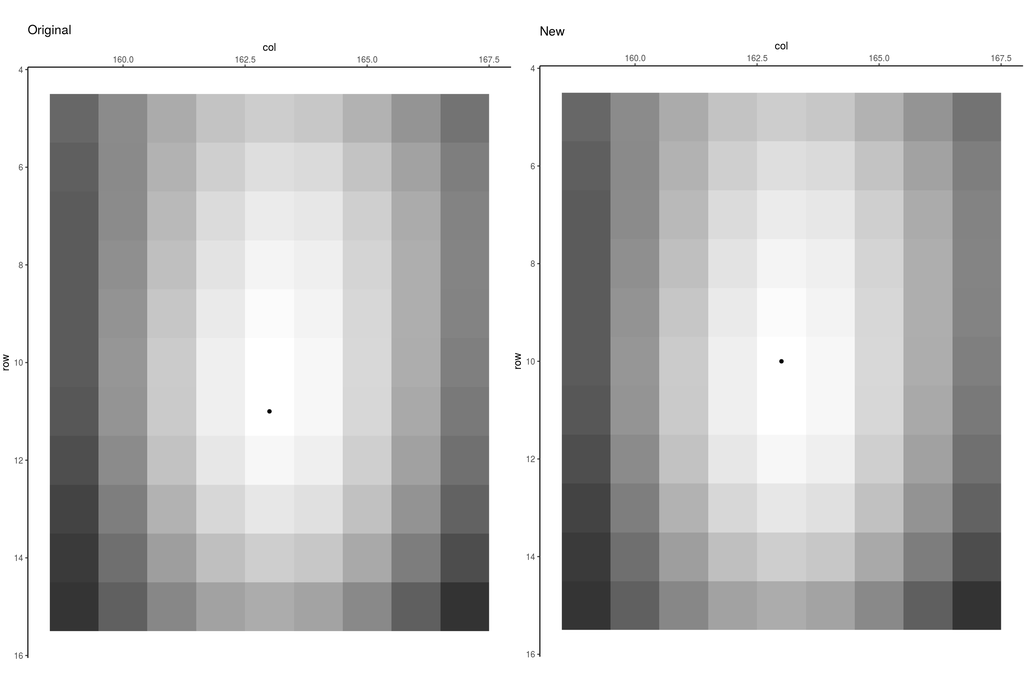

## Compare fill stats

We know the watersheds have different numbering, so first need to renumber all to match

```r
fill <- shedno_update2(fill)
orig_fill <- shedno_update2(orig_fill)
```

**Original Fill data**

|  | ShedNo | Edge | Final | ShedArea | PitRow | PitCol | PitRec | PitElev | PourElev | PreVol | PitVol | Varatio | PitArea | NextPit | Removed | InRow | InCol | InRec | InElev | OutRow | OutCol | OutRec | OutElev | Stage | Visited | Becomes | DrainsTo | EndPit |
| --- | --- | --- | --- | --- | --- | --- | --- | --- | --- | --- | --- | --- | --- | --- | --- | --- | --- | --- | --- | --- | --- | --- | --- | --- | --- | --- | --- | --- |
| 1 | 24 | False | False | 2699 | 112 | 143 | 20900 | 672.899 | 673.072 | 0 | 2.44 | 0.9 | 32 | 23 | True | 117 | 142 | 21834 | 673.072 | 118 | 143 | 22022 | 673.071 | 1 | False | 14 | 15 | 6 |
| 2 | 15 | False | False | 1490 | 139 | 136 | 25942 | 671.127 | 671.287 | 0 | 6.091 | 4.09 | 73 | 30 | True | 146 | 132 | 27247 | 671.284 | 147 | 132 | 27434 | 671.287 | 1 | False | 14 | 9 | 6 |
| 3 | 9 | True | False | 1377 | 169 | 122 | 31538 | 669.989 | 671.046 | 0 | 94.104 | 68.34 | 250 | 33 | True | 184 | 128 | 34349 | 671.046 | 184 | 129 | 34350 | 671.041 | 1 | True | 8 | 13 | 6 |
| 4 | 14 | False | False | 4189 | 139 | 136 | 25942 | 671.127 | 671.287 | 6.091 | 6.091 | 1.45 | 73 | 30 | True | 146 | 132 | 27247 | 671.284 | 147 | 132 | 27434 | 671.287 | 0 | False | 8 | 9 | 6 |
| 5 | 37 | False | False | 1171 | 57 | 149 | 10621 | 676.113 | 676.232 | 0 | 3.626 | 3.1 | 62 | 17 | True | 52 | 145 | 9682 | 676.228 | 51 | 144 | 9494 | 676.232 | 1 | False | 32 | 33 | 16 |
| 6 | 33 | True | False | 1296 | 11 | 163 | 2033 | 674.74 | 675.264 | 0 | 31.315 | 24.16 | 137 | 26 | True | 1 | 156 | 156 | 675.264 | 1 | 155 | 155 | 675.263 | 1 | True | 32 | 35 | 16 |
| 7 | 11 | False | False | 3984 | 156 | 64 | 29049 | 670.292 | 670.514 | 0 | 14.353 | 3.6 | 153 | 10 | True | 155 | 57 | 28855 | 670.512 | 155 | 56 | 28854 | 670.514 | 1 | False | 3 | 4 | 8 |
| 8 | 4 | False | False | 2022 | 156 | 39 | 29024 | 669.936 | 670.132 | 0 | 9.085 | 4.49 | 110 | 7 | True | 162 | 37 | 30144 | 670.132 | 163 | 36 | 30330 | 670.125 | 1 | False | 3 | 2 | 8 |
| 9 | 2 | True | False | 3287 | 165 | 1 | 30669 | 665.34 | 670.132 | 0 | 3441.443 | 1046.99 | 1483 | 38 | True | 163 | 36 | 30330 | 670.125 | 162 | 37 | 30144 | 670.132 | 1 | False | 1 | 4 | 8 |
| 10 | 3 | False | False | 6006 | 156 | 39 | 29024 | 669.936 | 670.132 | 9.085 | 9.085 | 1.51 | 110 | 7 | True | 162 | 37 | 30144 | 670.132 | 163 | 36 | 30330 | 670.125 | 0 | False | 1 | 2 | 8 |

[output cut: 32 more lines]

**New Fill data**

|  | ShedNo | Edge | Final | ShedArea | PitRow | PitCol | PitRec | PitElev | PourElev | PreVol | PitVol | Varatio | PitArea | NextPit | Removed | InRow | InCol | InRec | InElev | OutRow | OutCol | OutRec | OutElev | Stage | Visited | Becomes | DrainsTo | EndPit |
| --- | --- | --- | --- | --- | --- | --- | --- | --- | --- | --- | --- | --- | --- | --- | --- | --- | --- | --- | --- | --- | --- | --- | --- | --- | --- | --- | --- | --- |
| 1 | 24 | False | False | 2699 | 112 | 143 | 20900 | 672.899 | 673.072 | 0 | 2.44 | 0.9 | 32 | 23 | False | 117 | 142 | 21834 | 673.072 | 118 | 142 | 22021 | 673.066 | 0 | False | 14 | 15 | 6 |
| 2 | 15 | False | False | 1490 | 139 | 136 | 25942 | 671.127 | 671.287 | 0 | 6.091 | 4.09 | 73 | 30 | False | 146 | 132 | 27247 | 671.284 | 147 | 132 | 27434 | 671.287 | 0 | False | 14 | 9 | 6 |
| 3 | 9 | True | False | 1377 | 169 | 122 | 31538 | 669.989 | 671.046 | 0 | 94.104 | 68.34 | 250 | 33 | False | 184 | 128 | 34349 | 671.046 | 184 | 129 | 34350 | 671.041 | 0 | False | 8 | 13 | 6 |
| 4 | 14 | False | False | 4189 | 139 | 136 | 25942 | 671.127 | 671.287 | 0 | 6.091 | 1.45 | 73 | 30 | False | 146 | 132 | 27247 | 671.284 | 147 | 132 | 27434 | 671.287 | 0 | False | 8 | 9 | 6 |
| 5 | 33 | True | False | 1296 | 10 | 163 | 1846 | 674.74 | 675.264 | 0 | 31.315 | 24.16 | 137 | 26 | False | 1 | 156 | 156 | 675.264 | 1 | 155 | 155 | 675.263 | 0 | False | 32 | 35 | 16 |
| 6 | 37 | False | False | 1171 | 57 | 149 | 10621 | 676.113 | 676.232 | 0 | 3.626 | 3.1 | 62 | 17 | False | 52 | 145 | 9682 | 676.228 | 51 | 144 | 9494 | 676.232 | 0 | False | 32 | 33 | 16 |
| 7 | 11 | False | False | 3984 | 156 | 64 | 29049 | 670.292 | 670.514 | 0 | 14.357 | 3.6 | 155 | 10 | False | 154 | 57 | 28668 | 670.512 | 155 | 56 | 28854 | 670.514 | 0 | False | 3 | 4 | 8 |
| 8 | 4 | False | False | 2022 | 156 | 39 | 29024 | 669.936 | 670.132 | 0 | 9.085 | 4.49 | 110 | 7 | False | 162 | 37 | 30144 | 670.132 | 163 | 36 | 30330 | 670.125 | 0 | False | 3 | 2 | 8 |
| 9 | 2 | True | False | 3287 | 164 | 1 | 30482 | 665.34 | 670.132 | 0 | 3441.443 | 1046.99 | 1483 | 38 | False | 163 | 36 | 30330 | 670.125 | 162 | 37 | 30144 | 670.132 | 0 | False | 1 | 4 | 8 |
| 10 | 3 | False | False | 6006 | 156 | 39 | 29024 | 669.936 | 670.132 | 0 | 9.085 | 1.51 | 110 | 7 | False | 162 | 37 | 30144 | 670.132 | 163 | 36 | 30330 | 670.125 | 0 | False | 1 | 2 | 8 |

[output cut: 32 more lines]

- Order of pit filling is the same (with the exception of 37 and 33 which are reversed, but which doesn’t change any interpretations)

**Differences**

```r
fill <- arrange(fill, ShedNo)
orig_fill <- arrange(orig_fill, ShedNo)
c <- compare(fill, orig_fill)
```

```
## Pit Rec not all the same, but all within 1 cell
```

```
## Not all PreVol the same
```

```
## Pit Vol not the same, but within 1
```

```
## Varatio not the same, but within 5
```

```
## Pit area not the same, but within 3 cells
```

```
## Not all Removed the same
```

```
## In Rec not all the same, but all within 1 cell
```

```
## Out Rec not all the same, but all within 1 cell
```

```
## Out elev not all the same, but within 0.01
```

```
## Not all Stage the same
```

```
## Not all Visited the same
```

```
## Not all DrainsTo the same
```

- All important values (pit area, pit vol, varatio, becomes) are identical, or only different by a small degree
- Out sheds (DrainsTo) not all the same… does this matter?
- PreVol/Removed/Stage/Visited not used by LITAP

```
##    ShedNo PourElev PitRec DrainsTo OutRec InRec
## 10     10  670.724  34309       11  32428 32615
## 12     12  671.046  34357        8  34349 34350
## 23     23  673.462  21292       24  20534 20348
## 36     36  675.978  15109       24  16978 16791
```

```
##    ShedNo PourElev PitRec DrainsTo OutRec InRec
## 10     10  670.724  34309        3  32428 32615
## 12     12  671.046  34357        6  34349 34350
## 23     23  673.462  21292       14  20534 20348
## 36     36  675.978  15109        7  16978 16791
```

## Compare pit stats

We know the watersheds have different numbering, so first need to renumber all to match

```r
pit <- shedno_update2(pit)
orig_pit <- shedno_update2(orig_pit)
```

**Original Pit data**

|  | ShedNo | Edge | Final | ShedArea | PitRow | PitCol | PitRec | PitElev | PourElev | PreVol | PitVol | Varatio | PitArea | NextPit | Removed | InRow | InCol | InRec | InElev | OutRow | OutCol | OutRec | OutElev | Stage | Visited | Becomes | DrainsTo | EndPit |
| --- | --- | --- | --- | --- | --- | --- | --- | --- | --- | --- | --- | --- | --- | --- | --- | --- | --- | --- | --- | --- | --- | --- | --- | --- | --- | --- | --- | --- |
| 1 | 17 | False | True | 1142 | 12 | 79 | 2136 | 677.3 | 677.859 | 0 | 42.348 | 37.08 | 171 | 45 | False | 10 | 71 | 1754 | 677.859 | 10 | 70 | 1753 | 677.859 | 1 | True | 17 | 0 | 17 |
| 2 | 6 | False | True | 2404 | 44 | 1 | 8042 | 671.758 | 671.968 | 0 | 2.665 | 1.11 | 28 | 45 | False | 37 | 1 | 6733 | 671.968 | 36 | 1 | 6546 | 671.967 | 1 | True | 6 | 0 | 6 |
| 3 | 14 | False | True | 1826 | 5 | 138 | 886 | 674.982 | 675.264 | 0 | 9.813 | 5.37 | 70 | 26 | False | 1 | 144 | 144 | 675.264 | 1 | 145 | 145 | 675.256 | 1 | True | 14 | 15 | 14 |
| 4 | 18 | False | True | 73 | 1 | 94 | 94 | 678.989 | 679.094 | 0 | 1.078 | 14.77 | 21 | 5 | False | 1 | 98 | 98 | 679.082 | 1 | 99 | 99 | 679.094 | 1 | True | 18 | 14 | 18 |
| 5 | 10 | False | True | 579 | 10 | 187 | 1870 | 674.399 | 674.541 | 0 | 2.945 | 5.09 | 37 | 28 | False | 5 | 183 | 931 | 674.53 | 4 | 182 | 743 | 674.541 | 1 | True | 10 | 12 | 10 |
| 6 | 16 | False | True | 508 | 67 | 187 | 12529 | 677.155 | 677.829 | 0 | 51.191 | 100.77 | 160 | 40 | False | 63 | 177 | 11771 | 677.829 | 62 | 176 | 11583 | 677.822 | 1 | True | 16 | 0 | 16 |
| 7 | 11 | False | True | 400 | 159 | 184 | 29730 | 674.458 | 674.868 | 0 | 28.015 | 70.04 | 131 | 41 | False | 167 | 179 | 31221 | 674.868 | 168 | 178 | 31407 | 674.854 | 1 | True | 11 | 0 | 11 |
| 8 | 15 | False | True | 125 | 1 | 149 | 149 | 675.049 | 675.264 | 0 | 2.635 | 21.08 | 28 | 5 | False | 1 | 145 | 145 | 675.256 | 1 | 144 | 144 | 675.264 | 1 | True | 15 | 14 | 15 |
| 9 | 12 | False | True | 102 | 1 | 181 | 181 | 674.502 | 674.541 | 0 | 0.153 | 1.5 | 9 | 15 | False | 4 | 182 | 743 | 674.541 | 5 | 183 | 931 | 674.53 | 1 | True | 12 | 10 | 12 |
| 10 | 8 | False | True | 522 | 67 | 1 | 12343 | 672.386 | 672.473 | 0 | 1.16 | 2.22 | 26 | 4 | False | 60 | 1 | 11034 | 672.472 | 59 | 1 | 10847 | 672.473 | 1 | True | 8 | 6 | 8 |

[output cut: 8 more lines]

**New Pit data**

|  | ShedNo | Edge | Final | ShedArea | PitRow | PitCol | PitRec | PitElev | PourElev | PreVol | PitVol | Varatio | PitArea | NextPit | Removed | InRow | InCol | InRec | InElev | OutRow | OutCol | OutRec | OutElev | Stage | Visited | Becomes | DrainsTo | EndPit |
| --- | --- | --- | --- | --- | --- | --- | --- | --- | --- | --- | --- | --- | --- | --- | --- | --- | --- | --- | --- | --- | --- | --- | --- | --- | --- | --- | --- | --- |
| 1 | 17 | True | True | 1142 | 12 | 79 | 2136 | 677.3 | 677.859 | 0 | 42.348 | 37.08 | 171 | 45 | False | 10 | 71 | 1754 | 677.859 | 10 | 70 | 1753 | 677.859 | 0 | False | 17 | 0 | 17 |
| 2 | 6 | True | True | 2404 | 44 | 1 | 8042 | 671.758 | 671.968 | 0 | 2.665 | 1.11 | 28 | 45 | False | 37 | 1 | 6733 | 671.968 | 36 | 1 | 6546 | 671.967 | 0 | False | 6 | 0 | 6 |
| 3 | 14 | True | True | 1826 | 5 | 138 | 886 | 674.982 | 675.264 | 0 | 9.813 | 5.37 | 70 | 26 | False | 1 | 144 | 144 | 675.264 | 1 | 145 | 145 | 675.256 | 0 | False | 14 | 15 | 14 |
| 4 | 18 | True | True | 73 | 1 | 94 | 94 | 678.989 | 679.094 | 0 | 1.066 | 14.6 | 20 | 5 | False | 1 | 98 | 98 | 679.082 | 1 | 99 | 99 | 679.094 | 0 | False | 18 | 14 | 18 |
| 5 | 10 | True | True | 579 | 10 | 187 | 1870 | 674.399 | 674.541 | 0 | 2.934 | 5.07 | 36 | 28 | False | 5 | 183 | 931 | 674.53 | 4 | 182 | 743 | 674.541 | 0 | False | 10 | 12 | 10 |
| 6 | 16 | True | True | 508 | 66 | 187 | 12342 | 677.155 | 677.829 | 0 | 51.191 | 100.77 | 160 | 40 | False | 63 | 177 | 11771 | 677.829 | 62 | 176 | 11583 | 677.822 | 0 | False | 16 | 0 | 16 |
| 7 | 11 | True | True | 400 | 159 | 184 | 29730 | 674.458 | 674.868 | 0 | 28.015 | 70.04 | 131 | 41 | False | 167 | 179 | 31221 | 674.868 | 168 | 178 | 31407 | 674.854 | 0 | False | 11 | 0 | 11 |
| 8 | 15 | True | True | 125 | 1 | 149 | 149 | 675.049 | 675.264 | 0 | 2.635 | 21.08 | 28 | 5 | False | 1 | 145 | 145 | 675.256 | 1 | 144 | 144 | 675.264 | 0 | False | 15 | 14 | 15 |
| 9 | 12 | True | True | 102 | 1 | 181 | 181 | 674.502 | 674.541 | 0 | 0.153 | 1.5 | 9 | 15 | False | 4 | 182 | 743 | 674.541 | 5 | 183 | 931 | 674.53 | 0 | False | 12 | 10 | 12 |
| 10 | 8 | True | True | 522 | 67 | 1 | 12343 | 672.386 | 672.473 | 0 | 1.16 | 2.22 | 26 | 4 | False | 60 | 1 | 11034 | 672.472 | 59 | 1 | 10847 | 672.473 | 0 | False | 8 | 6 | 8 |

[output cut: 8 more lines]

**Differences**

```r
c <- compare(pit, orig_pit)
```

```
## Not all Edge the same
```

```
## Pit Rec not all the same, but all within 1 cell
```

```
## Not all PreVol the same
```

```
## Pit Vol not the same, but within 1
```

```
## Varatio not the same, but within 5
```

```
## Pit area not the same, but within 3 cells
```

```
## Not all Stage the same
```

```
## Not all Visited the same
```

Same conclusions as above

## Inverted DEM

Black dots indicate pits, or, as this is inverted, peaks

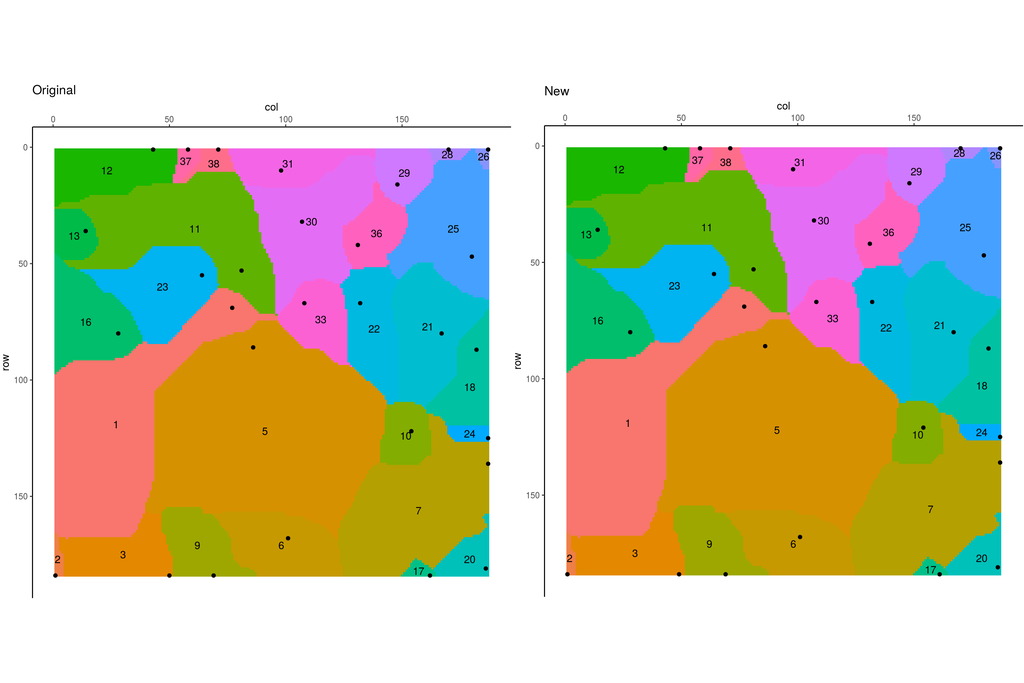

```r
c <- compare(ipit, orig_ipit)
```

```
## Not all Edge the same
```

```
## Shed area not the same, but within 3 cells
```

```
## Pit Rec not all the same, but all within 1 cell
```

```
## Pit Vol not the same, but within 1
```

```
## Varatio not the same, but within 5
```

```
## Pit area not the same, but within 3 cells
```

```
## Not all DrainsTo the same
```

```
## Not all InElev the same
```

```
## Out Rec not all the same, but all within 1 cell
```

```
## Out elev not all the same, but within 0.01
```

- Pit and Shed areas off by a small amount
- Leads to small differences in pit volume and varatio

Original vs. New differences in Pit volume:

```
##    ShedNo ShedArea PitArea PitVol Varatio
## 24     30     1953     316 70.552   36.12
## 27     36      641      89 10.684   16.67
```

```
##    ShedNo ShedArea PitArea PitVol Varatio
## 24     30     1953     315 71.144   36.43
## 27     36      642      89 10.702   16.67
```

Original vs. New differences in Varatio

```
##    ShedNo ShedArea PitArea  PitVol Varatio
## 17     22     1075      78  16.592   15.43
## 20     25     1784     332 195.497  109.58
## 23     29      498      47   5.389   10.82
## 24     30     1953     316  70.552   36.12
```

```
##    ShedNo ShedArea PitArea  PitVol Varatio
## 17     22     1074      78  16.592   15.45
## 20     25     1783     332 195.497  109.64
## 23     29      499      47   5.389   10.80
## 24     30     1953     315  71.144   36.43
```

- small differences in exact pit location (off by one cell at most)
- small differences in exact overflow point

Original vs. New differences in flow out point (seqno/row/col)

```
##    ShedNo PourElev PitRec OutRec OutRow OutCol OutElev
## 12     16    6.418  14801  13312     72     35   6.391
## 13     17    8.432  34382  34199    183    165   8.427
## 17     22    3.317  12474  12654     68    125   3.292
## 29     38    3.364     71   1940     11     70   3.361
```

```
##    ShedNo PourElev PitRec OutRec OutRow OutCol OutElev
## 12     16    6.418  14801  13499     73     35   6.410
## 13     17    8.432  34383  34386    184    165   8.429
## 17     22    3.317  12474  12841     69    125   3.301
## 29     38    3.364     71   1941     11     71   3.363
```